# Exercise 6

wenbo

## Conceptual

> Q1

#### (a)

Best subset.

#### (b)

Either one is possible.

#### (c)

i True

ii True

iii False

iv False

v False

### Q2

#### (a)

Chose iii. The reason is that lasso has penalty which restricts the flexibilty of the linear model. Therefore, it often decreases variance and increas bias.

#### (b)

Chose iii. The reason is similar to (a)

#### (c)

Chose ii. For non-linear models, they have more flexibility than linear models.

### Q3

#### (a)

Chose iv. For training set, The increasing of s is equivalent to increase the flexibility of the model, RSS will steadily decrease.

#### (b)

Chose ii. For test set, initially RSS will decrease then it will increase because of overfitting.

#### (c)

Chose iii. For variance, as flexvility increasing, variance will steadly increase.

#### (d)

Chose iv. For bias, as flexvility increasing, variance will steadly decrease.

#### (e)

Chose v. For irreducible error, it is a constant value and it is not correlated with the value of s.

### Q4

Increasing $\lambda$ from 0 means decrease the flexibility of the model

#### (a)

Chose iii.

#### (b)

Chose ii.

#### (c)

Chose iv.

#### (d)

Chose iii.

#### (e)

Chose v.

### Q5

#### (a)

$$min \quad \sum_{i=1}^2(yi-\sum_{j=1}^2\beta_jx_{ij})^2+ \lambda\sum_{j=1}^2\beta_j^2$$

#### (b)

We can obtain the $\hat\beta_1$ and $\hat\beta_2$ by making the first derivative of this optimization proble equal 0.

let $x_{11}=x_{12}=x_1$ and $x_{21}=x_{22}=x_2$
$$L=\sum_{i=1}^2(yi-\sum_{j=1}^2\beta_jx_{ij})^2+ \lambda\sum_{j=1}^2\beta_j^2\\
\frac{\alpha L}{\alpha \beta_1}=2\sum_{i=1}^2(yi-\sum_{j=1}^2\beta_jx_{ij})(-x_{i1})+2\lambda\beta_1=0\\
\rightarrow \quad \hat\beta_1=\frac{\sum_{i=1}^2y_ix_i-\hat\beta_2x_i^2}{\lambda+\sum_{i=1}^{2}x_i^2} -\,-(1)\\$$
Also, we can get the estimation of $\beta_2$ in a simialr way:
$$\rightarrow \quad \hat\beta_2=\frac{\sum_{i=1}^2y_ix_i-\hat\beta_1x_i^2}{\lambda+\sum_{i=1}^{2}x_i^2} -\,-(2)\\$$
By eliminating the terms in two equations, we can obtain that:
$$\hat{\beta_1}=\hat{\beta_2}$$

#### (c)

$$min \quad \sum_{i=1}^2(yi-\sum_{j=1}^2\beta_jx_{ij})^2+ \lambda\sum_{j=1}^2|\beta_j|$$

#### (d)

Then we assume that $\beta_j$ doesn’t equal 0.
$$L=\sum_{i=1}^2(yi-\sum_{j=1}^2\beta_jx_{ij})^2+ \lambda\sum_{j=1}^2|\beta_j|\\
\frac{\alpha L}{\alpha \beta_1}=2\sum_{i=1}^2(yi-\sum_{j=1}^2\beta_jx_{i})(-x_{i1})+\lambda\frac{|\beta_1|}{\beta_1}=0\\
\rightarrow \sum_{j=1}^2\sum_{i=1}^2\beta_jx_{i}+\lambda\frac{|\beta_1|}{\beta_1}=\sum_{i=1}^2y_ix_i \quad-\,-(1)\\$$
Similarly
$$L=\sum_{i=1}^2(yi-\sum_{j=1}^2\beta_jx_{ij})^2+ \lambda\sum_{j=1}^2|\beta_j|\\
\frac{\alpha L}{\alpha \beta_2}=2\sum_{i=1}^2(yi-\sum_{j=1}^2\beta_jx_{i})(-x_{i1})+\lambda\frac{|\beta_2|}{\beta_2}=0\\
\rightarrow \sum_{j=1}^2\sum_{i=1}^2\beta_jx_{i}+\lambda\frac{|\beta_2|}{\beta_2}=\sum_{i=1}^2y_ix_i \quad-\,-(2) \\$$
We notice that the right hand side for (1) and (2) are equal. By eliminating some terms, we obtain that:
$$\frac{\hat{|\beta_2|}}{\hat{\beta_2}}=\frac{\hat{|\beta_1|}}{\hat{\beta_1}}$$
Here we can see there are many solutions for this equation.

### Q6

#### (a)

Let y=8 and $\lambda=5$

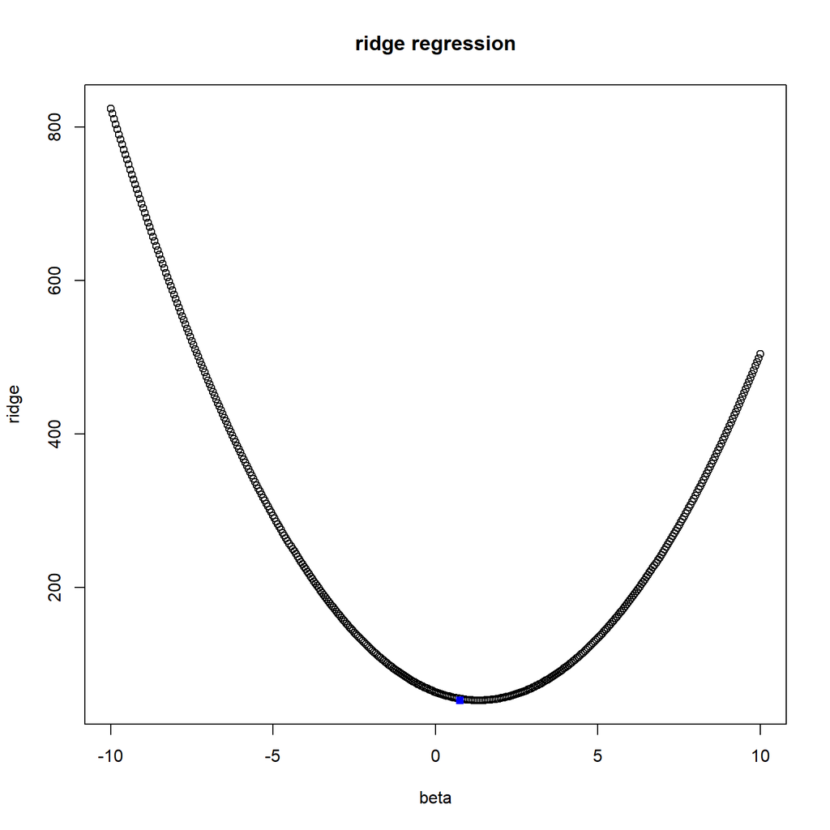

```r
beta=seq(-10,10,0.05)
ridge=(8-beta)^2+5*beta^2
plot(beta,ridge,main='ridge regression')
points(3/4,(8-4/3)^2+5*(4/3)^2,col='blue',pch=15)
```

It can be seen that $\hat{\beta}^R_j=y_j/(1+\lambda)=4/3$ optimizes the ridge regression equation.

#### (b)

Let y=8 and $\lambda=5$

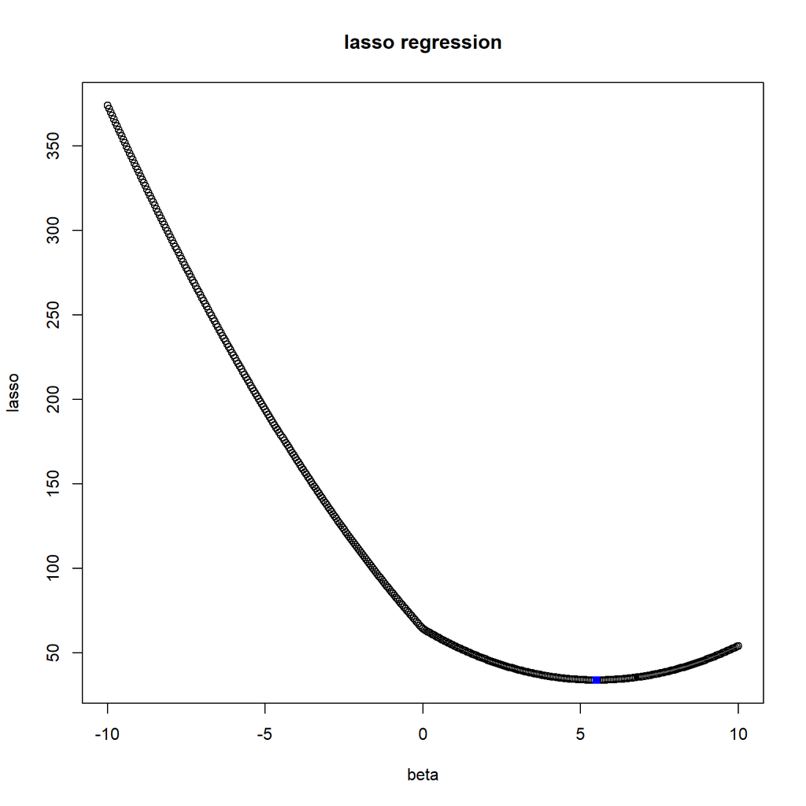

```r
beta=seq(-10,10,0.05)
lasso=(8-beta)^2+5*abs(beta)
plot(beta,lasso,main='lasso regression')
points(5.5,(8-5.5)^2+5*(5.5),col='blue',pch=15)
```

### Q7

#### (a)

$$\begin{aligned}
Likelihood&=P(\bf{y}|\beta)\\
&=\prod_{i=1}^n P(y_i|\beta,\delta^2)\\
&=\prod_{i=1}^n \frac{1}{\delta\sqrt{2\pi}}\exp(-\frac{(y_i-\beta_0+\sum_{j=1}^px_{ij}\beta_j)^2}{2\delta^2})\\
&=(\frac{1}{\delta\sqrt{2\pi}})^n\exp(-\frac{\sum_{i=1}^n(y_i-\beta_0+\sum_{j=1}^px_{ij}\beta_j)^2}{2\delta^2})
\end{aligned}$$

#### (b)

$$\begin{aligned}
Posterior&=(\frac{1}{\delta\sqrt{2\pi}})^n\exp(-\frac{\sum_{i=1}^n(y_i-\beta_0+\sum_{j=1}^px_{ij}\beta_j)^2}{2\delta^2})
\prod_{j=1}^p\frac{1}{2b}\exp(\frac{-|\beta_j|}{b})\\
&=(\frac{1}{\delta\sqrt{2\pi}})^n(\frac{1}{2b})^p\exp(-\frac{\sum_{i=1}^n(y_i-\beta_0+\sum_{j=1}^px_{ij}\beta_j)^2}{2\delta^2}+\sum_{j=1}^p\frac{-|\beta_j|}{b})
\end{aligned}$$

#### (c)

Since maximizing log from of a expression is equivalent to maximize itself. We can take a log on both sides.
$$\begin{aligned}
\log{Posterior}&=\log(\frac{1}{\delta\sqrt{2\pi}})^n(\frac{1}{2b})^p-\frac{\sum_{i=1}^n(y_i-\beta_0+\sum_{j=1}^px_{ij}\beta_j)^2}{2\delta^2}+\sum_{j=1}^p\frac{-|\beta_j|}{b}\\
\end{aligned}$$
$$\begin{aligned}
\mathop{argmax}\limits_{\beta}\quad Posterior&=\mathop{argmax}\limits_{\beta}\quad\log(\frac{1}{\delta\sqrt{2\pi}})^n(\frac{1}{2b})^p-\frac{\sum_{i=1}^n(y_i-\beta_0+\sum_{j=1}^px_{ij}\beta_j)^2}{2\delta^2}+\sum_{j=1}^p\frac{-|\beta_j|}{b}\\
&=\mathop{argmax}\limits_{\beta}\quad\sum_{i=1}^n-\frac{(y_i-\beta_0+\sum_{j=1}^px_{ij}\beta_j)^2}{2\delta^2}+\sum_{j=1}^p\frac{-|\beta_j|}{b}\\
&=\mathop{argmin}\limits_{\beta}\quad \frac{1}{2\delta^2}(\sum_{i=1}^n(y_i-\beta_0+\sum_{j=1}^px_{ij}\beta_j)^2{}+\sum_{j=1}^p\frac{2\delta^2}{b}|\beta_j|)\\
&=\mathop{argmin}\limits_{\beta}\quad \sum_{i=1}^n(y_i-\beta_0+\sum_{j=1}^px_{ij}\beta_j)^2{}+\sum_{j=1}^p\frac{2\delta^2}{b}|\beta_j|\\
&=\mathop{argmin}\limits_{\beta}\quad \sum_{i=1}^n(y_i-\beta_0+\sum_{j=1}^px_{ij}\beta_j)^2{}+\lambda\sum_{j=1}^p|\beta_j|\\
\text{by letting}\quad\lambda=\frac{2\delta^2}{b}
\end{aligned}$$
This is the lasso equation.

#### (d)

$$\begin{aligned}
Posterior&=\prod_{i=1}^n \frac{1}{\delta\sqrt{2\pi}}\exp(\frac{-(y_i-\beta_0+\sum_{j=1}^px_{ij}\beta_j)^2}{2\delta^2})
\prod_{j=1}^p\frac{1}{\sqrt{2\pi c}}\exp(\frac{-\beta_j^2}{2c})\\
&=(\frac{1}{\delta\sqrt{2\pi}})^n\exp(\frac{-\sum_{i=1}^n(y_i-\beta_0+\sum_{j=1}^px_{ij}\beta_j)^2}{2\delta^2})
(\frac{1}{\sqrt{2\pi c}})^p\exp(\frac{-\sum_{j=1}^p\beta_j^2}{2c})
\end{aligned}$$

#### (e)

Firstly, take the log on both sides:
$$\log Posterior=\log(\frac{1}{\delta\sqrt{2\pi}})^n(\frac{1}{\sqrt{2\pi c}})^p+\frac{-\sum_{i=1}^n(y_i-\beta_0+\sum_{j=1}^px_{ij}\beta_j)^2}{2\delta^2}
+\frac{-\sum_{j=1}^p\beta_j^2}{2c}$$
$$\begin{aligned}
\mathop{argmax}\limits_{\beta} \quad Posterior&=\mathop{argmax}\limits_{\beta} \quad \log(\frac{1}{\delta\sqrt{2\pi}})^n(\frac{1}{\sqrt{2\pi c}})^p+\frac{-\sum_{i=1}^n(y_i-\beta_0+\sum_{j=1}^px_{ij}\beta_j)^2}{2\delta^2}
-\frac{\sum_{j=1}^p\beta_j^2}{2c}\\
&=\mathop{argmax}\limits_{\beta}\quad\frac{-\sum_{i=1}^n(y_i-\beta_0+\sum_{j=1}^px_{ij}\beta_j)^2}{2\delta^2}
-\frac{\sum_{j=1}^p\beta_j^2}{2c}\\
&=\mathop{argmin}\limits_{\beta}\quad\frac{1}{2\delta^2}(\sum_{i=1}^n(y_i-\beta_0+\sum_{j=1}^px_{ij}\beta_j)^2+\frac{2\delta^2}{2c}\sum_{j=1}^p\beta_j^2)\\
&=\mathop{argmin}\limits_{\beta}\quad\sum_{i=1}^n(y_i-\beta_0+\sum_{j=1}^px_{ij}\beta_j)^2+\frac{2\delta^2}{2c}\sum_{j=1}^p\beta_j^2\\
&=\mathop{argmin}\limits_{\beta}\quad\sum_{i=1}^n(y_i-\beta_0+\sum_{j=1}^px_{ij}\beta_j)^2+\lambda\sum_{j=1}^p\beta_j^2\\
\text{by letting} \quad \lambda=\frac{2\delta^2}{2c}
\end{aligned}$$
This is the equation from of ridge regression.

## Applied

### Q8

#### (a)

```r
set.seed(1)
x=rnorm(100)
epi=rnorm(100)
```

#### (b)

```r
Y=1+2*x+3*x^2+4*x^3+epi
```

#### (c)

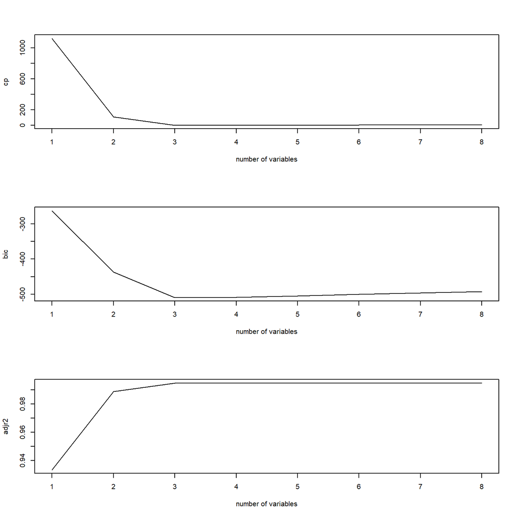

```r
library(leaps)
new_x=data.frame(x,x^2,x^3,x^4,x^5,x^6,x^7,x^8,x^9,x^10,Y)
reg.fit=regsubsets(Y~.,new_x)
reg.summary=summary(reg.fit)
par(mfrow=c(3,1))
#can plot with one dimension data
plot(reg.summary$cp,xlab = 'number of variables',ylab='cp',type='l')
plot(reg.summary$bic,xlab = 'number of variables',ylab='bic',type='l')
plot(reg.summary$adjr2,xlab = 'number of variables',ylab='adjr2',type='l')
```

```r
number=c(which.min(reg.summary$cp),which.min(reg.summary$bic),which.max(reg.summary$adjr2))
number
```

```
## [1] 4 3 4
```

```r
coef(reg.fit,4)
```

```
## (Intercept)           x         x.2         x.3         x.5
##  1.07200775  2.38745596  2.84575641  3.55797426  0.08072292
```

```r
coef(reg.fit,3)
```

```
## (Intercept)           x         x.2         x.3
##    1.061507    1.975280    2.876209    4.017639
```

```r
coef(reg.fit,4)
```

```
## (Intercept)           x         x.2         x.3         x.5
##  1.07200775  2.38745596  2.84575641  3.55797426  0.08072292
```

The best models for 3 criteria are not the same and they are shown above.

#### (d)

```r
reg.fwd=regsubsets(Y~.,new_x,nvmax=10,method='forward')
reg.summary1=summary(reg.fwd)
par(mfrow=c(2,2))
#can plot with one dimension data
plot(reg.summary1$cp,xlab = 'number of variables',ylab='cp',type='l')
plot(reg.summary1$bic,xlab = 'number of variables',ylab='bic',type='l')
plot(reg.summary1$adjr2,xlab = 'number of variables',ylab='adjr2',type='l')
number=c(which.min(reg.summary1$cp),which.min(reg.summary1$bic),which.max(reg.summary1$adjr2))
number
```

```
## [1] 4 3 4
```

[figure not shown]

```r
reg.bwd=regsubsets(Y~.,new_x,nvmax=10,method='forward')
reg.summary2=summary(reg.bwd)
par(mfrow=c(3,1))
```

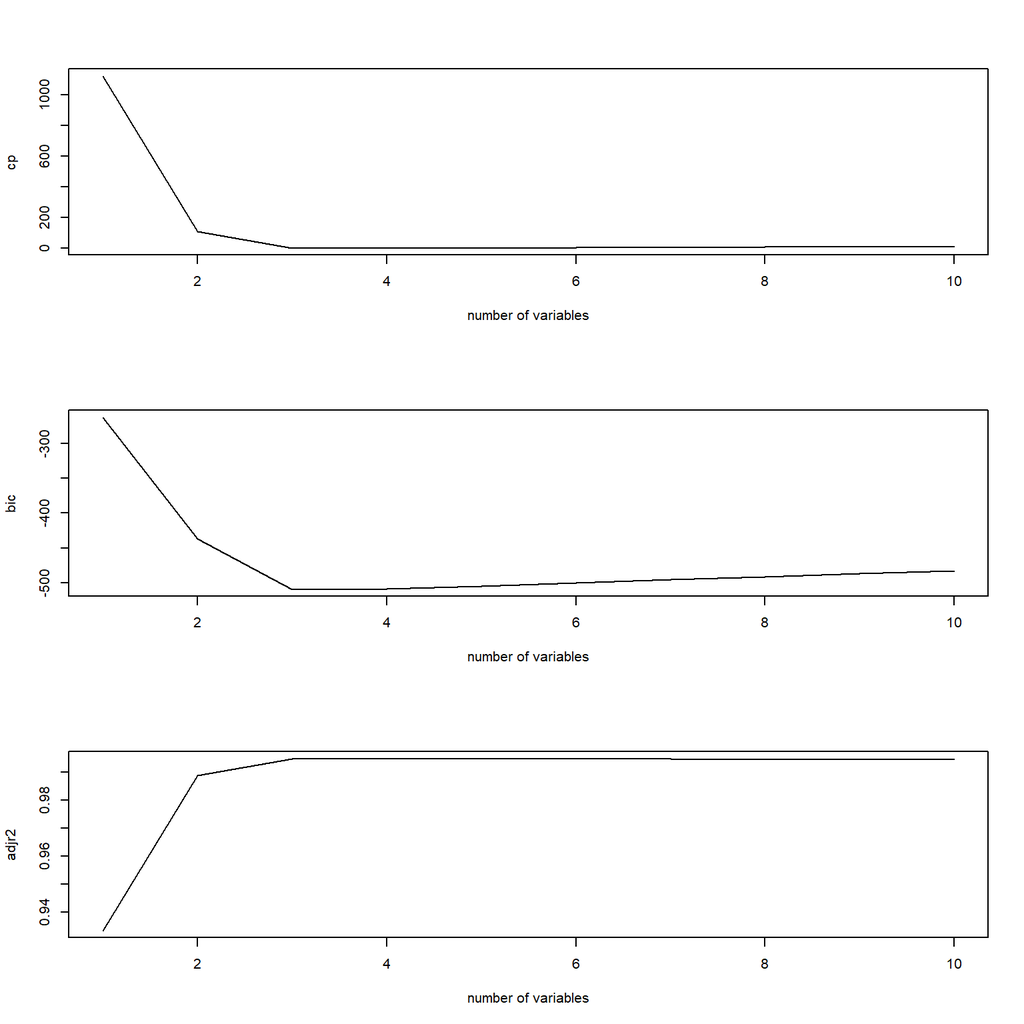

```r
#can plot with one dimension data
plot(reg.summary2$cp,xlab = 'number of variables',ylab='cp',type='l')
plot(reg.summary2$bic,xlab = 'number of variables',ylab='bic',type='l')
plot(reg.summary2$adjr2,xlab = 'number of variables',ylab='adjr2',type='l')
```

```r
number=c(which.min(reg.summary2$cp),which.min(reg.summary2$bic),which.max(reg.summary2$adjr2))
number
```

```
## [1] 4 3 4
```

```r
reg.summary1
```

```
## Subset selection object
## Call: regsubsets.formula(Y ~ ., new_x, nvmax = 10, method = "forward")
## 10 Variables  (and intercept)
##      Forced in Forced out
## x        FALSE      FALSE
## x.2      FALSE      FALSE
## x.3      FALSE      FALSE
## x.4      FALSE      FALSE
## x.5      FALSE      FALSE
## x.6      FALSE      FALSE
## x.7      FALSE      FALSE
## x.8      FALSE      FALSE
## x.9      FALSE      FALSE
## x.10     FALSE      FALSE
## 1 subsets of each size up to 10
## Selection Algorithm: forward
##           x   x.2 x.3 x.4 x.5 x.6 x.7 x.8 x.9 x.10
## 1  ( 1 )  " " " " "*" " " " " " " " " " " " " " "
## 2  ( 1 )  " " "*" "*" " " " " " " " " " " " " " "
## 3  ( 1 )  "*" "*" "*" " " " " " " " " " " " " " "
## 4  ( 1 )  "*" "*" "*" " " "*" " " " " " " " " " "
## 5  ( 1 )  "*" "*" "*" " " "*" "*" " " " " " " " "
## 6  ( 1 )  "*" "*" "*" " " "*" "*" " " " " "*" " "
## 7  ( 1 )  "*" "*" "*" " " "*" "*" "*" " " "*" " "
## 8  ( 1 )  "*" "*" "*" " " "*" "*" "*" "*" "*" " "
## 9  ( 1 )  "*" "*" "*" " " "*" "*" "*" "*" "*" "*"
## 10  ( 1 ) "*" "*" "*" "*" "*" "*" "*" "*" "*" "*"
```

```r
reg.summary2
```

```
## Subset selection object
## Call: regsubsets.formula(Y ~ ., new_x, nvmax = 10, method = "forward")
## 10 Variables  (and intercept)
##      Forced in Forced out
## x        FALSE      FALSE
## x.2      FALSE      FALSE
## x.3      FALSE      FALSE
## x.4      FALSE      FALSE
## x.5      FALSE      FALSE
## x.6      FALSE      FALSE
## x.7      FALSE      FALSE
## x.8      FALSE      FALSE
## x.9      FALSE      FALSE
## x.10     FALSE      FALSE
## 1 subsets of each size up to 10
## Selection Algorithm: forward
##           x   x.2 x.3 x.4 x.5 x.6 x.7 x.8 x.9 x.10
## 1  ( 1 )  " " " " "*" " " " " " " " " " " " " " "
## 2  ( 1 )  " " "*" "*" " " " " " " " " " " " " " "
## 3  ( 1 )  "*" "*" "*" " " " " " " " " " " " " " "
## 4  ( 1 )  "*" "*" "*" " " "*" " " " " " " " " " "
## 5  ( 1 )  "*" "*" "*" " " "*" "*" " " " " " " " "
## 6  ( 1 )  "*" "*" "*" " " "*" "*" " " " " "*" " "
## 7  ( 1 )  "*" "*" "*" " " "*" "*" "*" " " "*" " "
## 8  ( 1 )  "*" "*" "*" " " "*" "*" "*" "*" "*" " "
## 9  ( 1 )  "*" "*" "*" " " "*" "*" "*" "*" "*" "*"
## 10  ( 1 ) "*" "*" "*" "*" "*" "*" "*" "*" "*" "*"
```

Same answer with (c).

#### (e)

```r
library(glmnet)
```

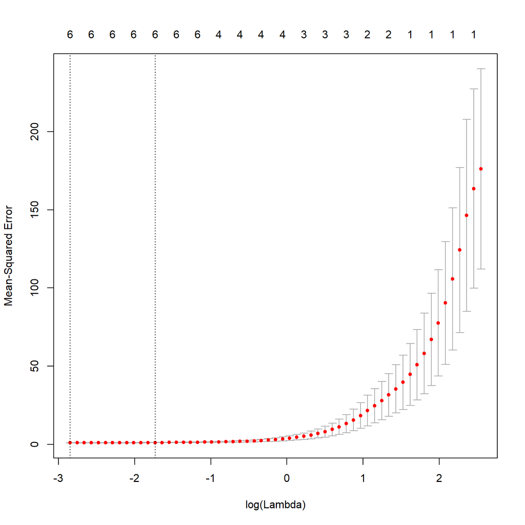

```r
library(magrittr)
grid=10^seq(10,-2,length=100)
xx=model.matrix(Y~.,new_x)[,-1]
cv.out=cv.glmnet(xx,Y,alpha=1)
plot(cv.out)
```

```r
bestlam=cv.out$lambda.min
#glmnet(xx,Y,lambda=grid) %>% predict(type='coefficients',s=bestlam)[1:11,]
out=glmnet(xx,Y,lambda=grid)
predict(out,type='coefficients',s=bestlam)[1:11,]
```

```
## (Intercept)           x         x.2         x.3         x.4         x.5
##  1.17017645  2.17605114  2.63586627  3.77660851  0.04248355  0.02420237
##         x.6         x.7         x.8         x.9        x.10
##  0.00000000  0.00290213  0.00000000  0.00000000  0.00000000
```

From $\beta_1$ to $\beta_3$, all the predictors are assigned substantial weights. For other predictors, they gives less influence.

#### (f)

```r
Y=1+7*x^7+epi
new_x=data.frame(x,x^2,x^3,x^4,x^5,x^6,x^7,x^8,x^9,x^10,Y)
reg.fit=regsubsets(Y~.,new_x)
reg.summary=summary(reg.fit)
par(mfrow=c(2,2))
#can plot with one dimension data
plot(reg.summary$cp,xlab = 'number of variables',ylab='cp',type='l')
plot(reg.summary$bic,xlab = 'number of variables',ylab='bic',type='l')
plot(reg.summary$adjr2,xlab = 'number of variables',ylab='adjr2',type='l')
number=c(which.min(reg.summary$cp),which.min(reg.summary$bic),which.max(reg.summary$adjr2))
number
```

```
## [1] 2 1 4
```

```r
coef(reg.fit,4)
```

```
## (Intercept)           x         x.2         x.3         x.7
##   1.0762524   0.2914016  -0.1617671  -0.2526527   7.0091338
```

```r
coef(reg.fit,3)
```

```
## (Intercept)         x.2         x.5         x.7
##   1.0862698  -0.1618472  -0.0599260   7.0133154
```

```r
coef(reg.fit,4)
```

```
## (Intercept)           x         x.2         x.3         x.7
##   1.0762524   0.2914016  -0.1617671  -0.2526527   7.0091338
```

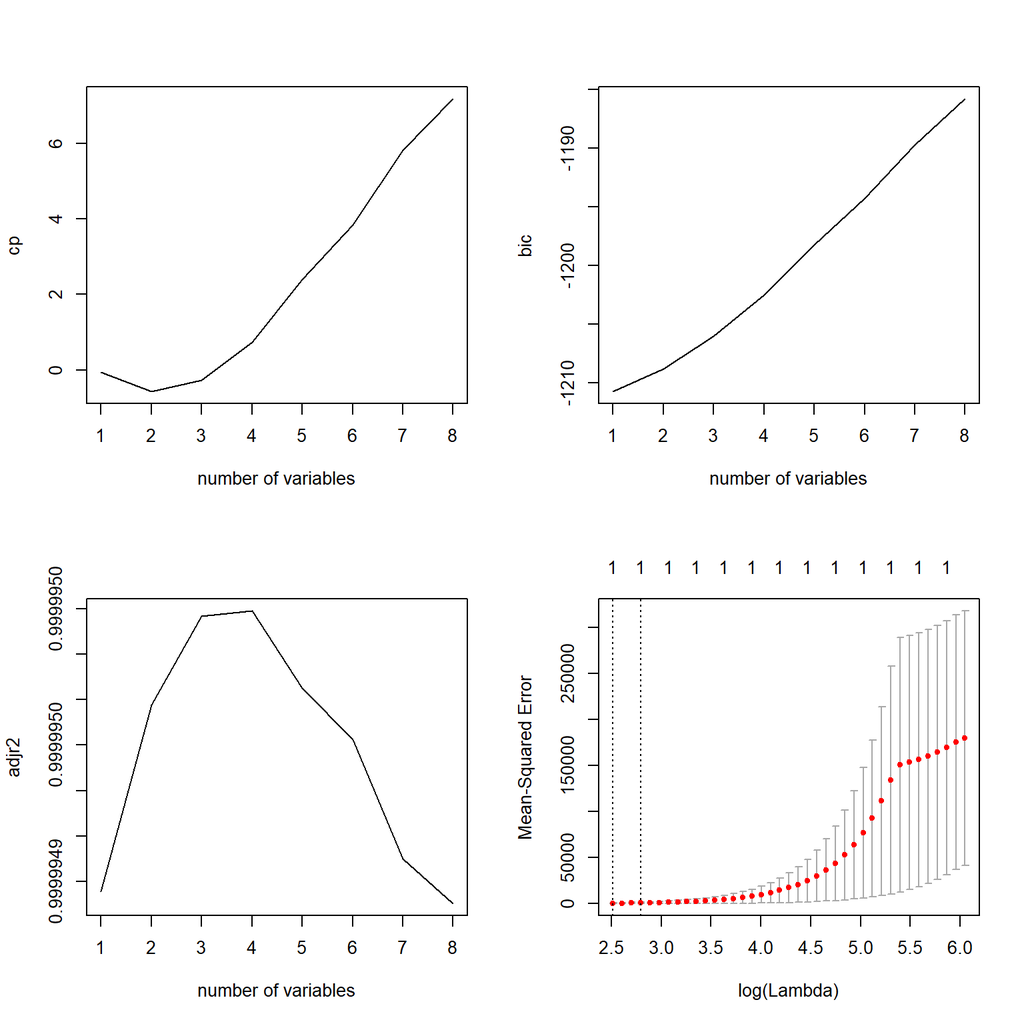

```r
xx=model.matrix(Y~.,new_x)[,-1]
cv.out=cv.glmnet(xx,Y,alpha=1)
plot(cv.out)
```

```r
bestlam=cv.out$lambda.min
#glmnet(xx,Y,lambda=grid) %>% predict(type='coefficients',s=bestlam)[1:11,]
out=glmnet(xx,Y,lambda=grid)
predict(out,type='coefficients',s=bestlam)[1:11,]
```

```
## (Intercept)           x         x.2         x.3         x.4         x.5
##    1.820215    0.000000    0.000000    0.000000    0.000000    0.000000
##         x.6         x.7         x.8         x.9        x.10
##    0.000000    6.796694    0.000000    0.000000    0.000000
```

### Q9

#### (a)

```r
library(ISLR)
train_index=sample(777,600,replace=FALSE)
train=College[train_index,]
test=College[-train_index,]
```

#### (b)

```r
lm.fit=lm(Apps~.,train)
pre=predict(lm.fit,test)
err.lm=mean((pre-test$Apps)^2)
mean((pre-test$Apps)^2)
```

```
## [1] 668476
```

#### (c)

```r
grid=10^seq(10,-2,length=100)
train=sample(777,600,replace=FALSE)
test=-train
x=model.matrix(Apps~.,College)[,-1]
y=College$Apps
ridge.mod=glmnet(x[train,],y[train],alpha=0,lambda=grid)
cv.out=cv.glmnet(x[train,],y[train],alpha=0)
bestlam=cv.out$lambda.min
ridge.pred=predict(ridge.mod,s=bestlam,newx=x[test,])
err.ridge=mean((ridge.pred-y[test])^2)
mean((ridge.pred-y[test])^2)
```

```
## [1] 1243058
```

```r
coef(ridge.mod)[,18]
```

```
##   (Intercept)    PrivateYes        Accept        Enroll     Top10perc
##  3.034889e+03 -1.839221e-01  6.799176e-05  1.640162e-04  3.518793e-03
##     Top25perc   F.Undergrad   P.Undergrad      Outstate    Room.Board
##  3.338727e-03  3.071288e-05  5.843315e-05  2.492941e-06  2.526107e-05
##         Books      Personal           PhD      Terminal     S.F.Ratio
##  1.633314e-04  4.586687e-05  4.382170e-03  4.466248e-03  4.325403e-03
##   perc.alumni        Expend     Grad.Rate
## -1.538424e-03  1.020503e-05  1.615674e-03
```

#### (d)

```r
lasso.mod=glmnet(x[train,],y[train],alpha=1,lambda=grid)
cv.out=cv.glmnet(x[train,],y[train],alpha=1)
bestlam=cv.out$lambda.min
lasso.pred=predict(lasso.mod,s=bestlam,newx=x[test,])
err.lasso=mean((lasso.pred-y[test])^2)
mean((lasso.pred-y[test])^2)
```

```
## [1] 1122837
```

```r
coef=predict(lasso.mod,type="coefficients",s=bestlam,newx=x[test,])
length(coef[coef!=0])
```

```
## <sparse>[ <logic> ] : .M.sub.i.logical() maybe inefficient
```

```
## [1] 15
```

#### (e)

```r
library(pls)
```

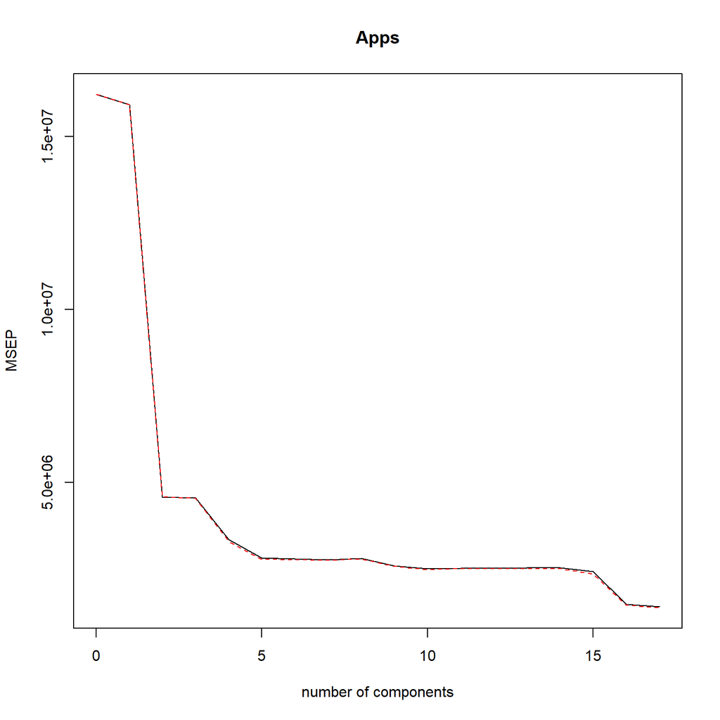

```r
set.seed(1)
pcr.fit=pcr(Apps~.,data=College,subset=train,scale=TRUE,validation='CV')
validationplot(pcr.fit,val.type='MSEP')
```

```r
pcr.pred=predict(pcr.fit,x[test,],ncomp=17)
err.pcr=mean((pcr.pred-y[test])^2)
mean((pcr.pred-y[test])^2)
```

```
## [1] 1127008
```

#### (f)

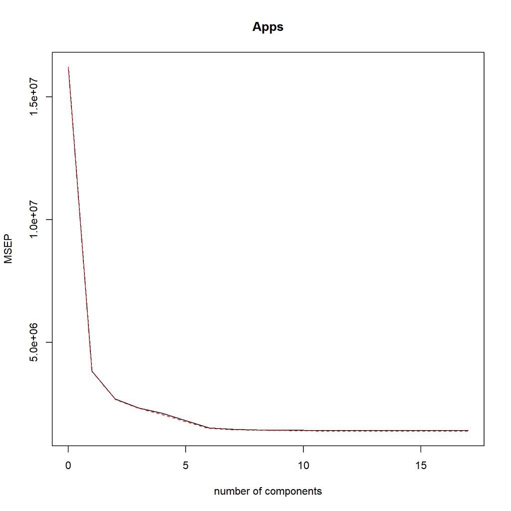

```r
set.seed(1)
pls.fit=plsr(Apps~.,data=College,subset=train,scale=TRUE,validation='CV')
validationplot(pls.fit,val.type='MSEP')
```

```r
pls.pred=predict(pls.fit,x[test,],ncomp=12)
err.pls=mean((pls.pred-y[test])^2)
mean((pls.pred-y[test])^2)
```

```
## [1] 1124830
```

#### (g)

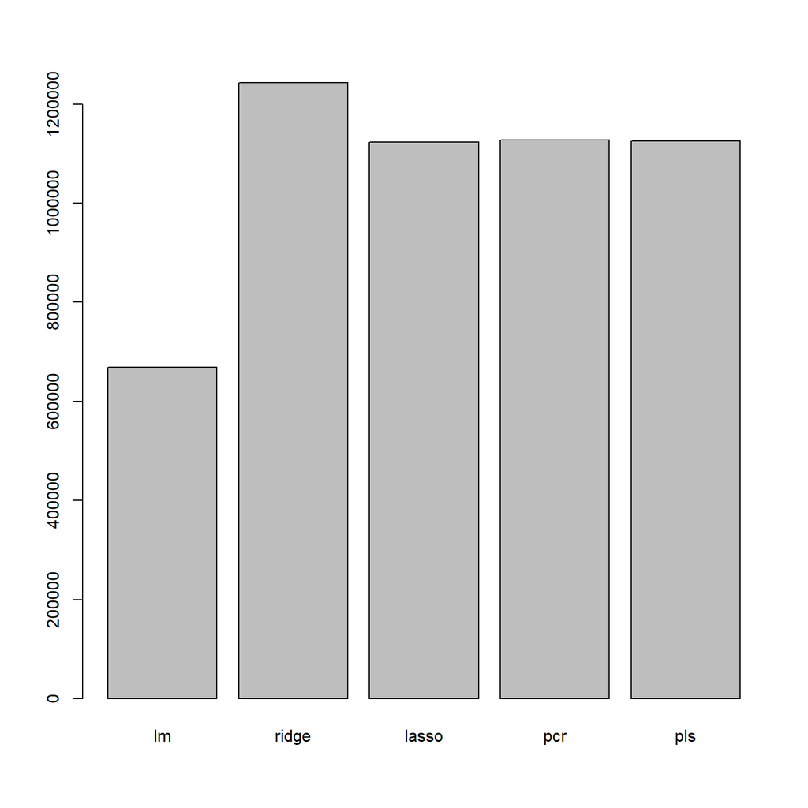

```r
err=c(err.lm,err.ridge,err.lasso,err.pcr,err.pls)
names(err)=c('lm','ridge','lasso','pcr','pls')
barplot(err)
```